# Week4 Assignment

### **Description:**

The best popular movies will be decided by rating and votes of the movies. Rating ranges from 1 to 10. The higher score of the rating, the better the movie is. The summary of rating shows that the 3rd quantile of rating is 7.0. Therefore, a cutoff at 7.0 and above will be defined as good movie. THe popularity is defined by higher votes. However, votes range from 5 to 157,608 and increase dramatically over time. It’s not fair to use one number to cutoff for the overall votes. Therefore, a cutoff votes for each year was calculated by mean of votes plus one standand deviation for that specific year. Then the year-customized cutoff were applied for the votes to filter the popular movies for the specific year. After the whole dataset were filtered by the two criteria above, the records were grouped by year and sorted by the total movies of year in descending order along with average rating and average votes for the year.

### **Methods:**

Load packages

```r
require("ggplot2")
require("dplyr")
```

Read in the dataset

```r
movie <- read.table("movies.tab", sep="\t", header=TRUE, quote="", comment="", stringsAsFactors = FALSE)
summary(movie)
```

```
##     title                year          length         budget
##  Length:58788       Min.   :1893   Min.   :   1   Min.   :0.00e+00
##  Class :character   1st Qu.:1958   1st Qu.:  74   1st Qu.:2.50e+05
##  Mode  :character   Median :1983   Median :  90   Median :3.00e+06
##                     Mean   :1976   Mean   :  82   Mean   :1.34e+07
##                     3rd Qu.:1997   3rd Qu.: 100   3rd Qu.:1.50e+07
##                     Max.   :2005   Max.   :5220   Max.   :2.00e+08
##                                                   NA's   :53573
##      rating          votes              r1               r2
##  Min.   : 1.00   Min.   :     5   Min.   :  0.00   Min.   : 0.00
##  1st Qu.: 5.00   1st Qu.:    11   1st Qu.:  0.00   1st Qu.: 0.00
##  Median : 6.10   Median :    30   Median :  4.50   Median : 4.50
##  Mean   : 5.93   Mean   :   632   Mean   :  7.01   Mean   : 4.02
##  3rd Qu.: 7.00   3rd Qu.:   112   3rd Qu.:  4.50   3rd Qu.: 4.50
##  Max.   :10.00   Max.   :157608   Max.   :100.00   Max.   :84.50
##
##        r3              r4               r5              r6
##  Min.   : 0.00   Min.   :  0.00   Min.   :  0.0   Min.   : 0.0
##  1st Qu.: 0.00   1st Qu.:  0.00   1st Qu.:  4.5   1st Qu.: 4.5
##  Median : 4.50   Median :  4.50   Median :  4.5   Median :14.5
##  Mean   : 4.72   Mean   :  6.37   Mean   :  9.8   Mean   :13.0
##  3rd Qu.: 4.50   3rd Qu.:  4.50   3rd Qu.: 14.5   3rd Qu.:14.5
##  Max.   :84.50   Max.   :100.00   Max.   :100.0   Max.   :84.5
##
##        r7              r8              r9              r10
##  Min.   :  0.0   Min.   :  0.0   Min.   :  0.00   Min.   :  0.0
##  1st Qu.:  4.5   1st Qu.:  4.5   1st Qu.:  4.50   1st Qu.:  4.5
##  Median : 14.5   Median : 14.5   Median :  4.50   Median : 14.5
##  Mean   : 15.6   Mean   : 13.9   Mean   :  8.95   Mean   : 16.9
##  3rd Qu.: 24.5   3rd Qu.: 24.5   3rd Qu.: 14.50   3rd Qu.: 24.5
##  Max.   :100.0   Max.   :100.0   Max.   :100.00   Max.   :100.0
##
##      mpaa               Action         Animation          Comedy
##  Length:58788       Min.   :0.0000   Min.   :0.0000   Min.   :0.000
##  Class :character   1st Qu.:0.0000   1st Qu.:0.0000   1st Qu.:0.000
##  Mode  :character   Median :0.0000   Median :0.0000   Median :0.000
##                     Mean   :0.0797   Mean   :0.0628   Mean   :0.294
##                     3rd Qu.:0.0000   3rd Qu.:0.0000   3rd Qu.:1.000
##                     Max.   :1.0000   Max.   :1.0000   Max.   :1.000
##
##      Drama        Documentary        Romance           Short
##  Min.   :0.000   Min.   :0.0000   Min.   :0.0000   Min.   :0.000
##  1st Qu.:0.000   1st Qu.:0.0000   1st Qu.:0.0000   1st Qu.:0.000
##  Median :0.000   Median :0.0000   Median :0.0000   Median :0.000
##  Mean   :0.371   Mean   :0.0591   Mean   :0.0807   Mean   :0.161
##  3rd Qu.:1.000   3rd Qu.:0.0000   3rd Qu.:0.0000   3rd Qu.:0.000
##  Max.   :1.000   Max.   :1.0000   Max.   :1.0000   Max.   :1.000
##
```

Summary of rating shows the range and quantiles. Using the 3rd quantile (7.0) as cutoff rating.

```r
summary(movie$rating)
```

```
##    Min. 1st Qu.  Median    Mean 3rd Qu.    Max.
##    1.00    5.00    6.10    5.93    7.00   10.00
```

Summary of votes shows wide range for votes. Can not use one cutoff for all dataset.

```r
summary(movie$votes)
```

```
##    Min. 1st Qu.  Median    Mean 3rd Qu.    Max.
##       5      11      30     632     112  158000
```

A plot of votes over the year with rating above 7.0 marked red color. The plot shows that movies with higher votes usually received higher rating in specific year. Overall votes increase dramatically over time.

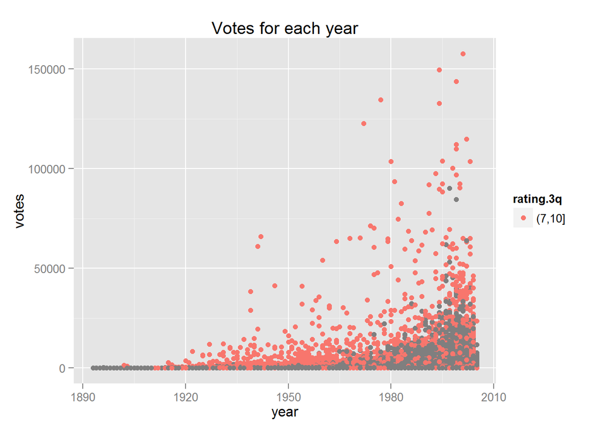

```r
rating.3q <- cut(movie$rating, c(7, 10))
ggplot(data = movie, aes(x = year, y = votes)) + geom_point(aes(colour = rating.3q)) + ggtitle("Votes for each year")
```

Therefore, a series of steps were done to create a year-customized cutoff for the votes.

Step 1. Create dataframe that has year and a cutoff votes for each year using mean plus 1 SD

```r
votes.1sd <- movie%>%
  select(year, votes)%>%
  group_by(year)%>%
  summarise(votes.1sd = mean(votes) + sd(votes))
```

Step 2. Create dataframe with only ‘year’, ‘rating’ and ‘votes’

```r
moviefilter <- movie %>%
  select(year, rating, votes)
```

Step3. Join the two dataframes created above.

```r
count<- merge(moviefilter, votes.1sd)
```

Step4. Select records with rating above 7.0 and votes higher than mean + 1SD for the year. Year 1893 was excluded from the dataset since there is only one movie in that year.

```r
count1 <-count%>%
  mutate(ifcount = (votes > votes.1sd))%>%
  filter(year!= 1893)%>%
  select(year, rating, votes, ifcount) %>%
  filter(rating > 7.0, ifcount == TRUE)
```

List the records grouped by year and sorted by the total movies of year in descending order along with average rating and average votes for the year.

```r
count2 <- count1%>%
  select(year, rating, votes)%>%
  group_by(year) %>%
  summarise(total = length(year), avg.rating = mean(rating), avg.votes = mean(votes))%>%
  arrange(desc(total))
head(count2)
```

```
## Source: local data frame [6 x 4]
##
##   year total avg.rating avg.votes
## 1 2002    44      7.580     23810
## 2 2004    39      7.715     18139
## 3 2003    36      7.675     22239
## 4 1998    30      7.587     25759
## 5 1999    30      7.700     37539
## 6 2000    30      7.687     28401
```

As seen, year 2002 made the most (44) movies which has popular votes and rating higher than 7.0. The movies were listed with title, year, rating and votes with rating in descending order.

```r
votes.cut <- function(whichyear){
  SD <- votes.1sd%>%filter(year == whichyear)
  return(SD[1,2])
}

show <- movie%>%
    select(title, year, rating, votes)%>%
    filter(year == 2002, rating > 7.0, votes>votes.cut(2002))%>%
    arrange(desc(rating))
head(show)
```

```
##                                    title year rating  votes
## 1 Lord of the Rings: The Two Towers, The 2002    8.8 114797
## 2                         Cidade de Deus 2002    8.7  25964
## 3                  Bowling for Columbine 2002    8.5  36747
## 4                           Pianist, The 2002    8.5  30467
## 5                         Hable con ella 2002    8.1  12609
## 6                             In America 2002    8.1   8371
```

### **Conclusion:**

Year 2002 made the best popular movies.

### **Discussion:**

The definition of the ‘best’ ‘popular’ will change the algorithm, therefore the conclusion. Let’s change the criteria of rating from 7.0 to 8.0. Data showed that year 2004 is the year made the best popular movies. This project is open for different interpretation

```r
count3 <-count%>%
  mutate(ifcount = (votes > votes.1sd))%>%
  filter(year!= 1893)%>%
  select(year, rating, votes, ifcount) %>%
  filter(rating > 8.0, ifcount == TRUE) %>%
  select(year, rating, votes)%>%
  group_by(year) %>%
  summarise(total = length(year), avg.rating = mean(rating), avg.votes = mean(votes))%>%
  arrange(desc(total))

head(count3)
```

```
## Source: local data frame [6 x 4]
##
##   year total avg.rating avg.votes
## 1 2004     9      8.322     23118
## 2 1957     7      8.400     12268
## 3 1999     7      8.286     82669
## 4 2002     7      8.400     36155
## 5 2003     6      8.367     43021
## 6 1940     5      8.260      9385
```

```r
show1 <- movie%>%
    select(title, year, rating, votes)%>%
    filter(year == 2004, rating > 8.0, votes>votes.cut(2004))%>%
    arrange(desc(rating))

head(show1)
```

```
##                                   title year rating votes
## 1 Eternal Sunshine of the Spotless Mind 2004    8.6 46240
## 2                          Hotel Rwanda 2004    8.5  8328
## 3                        Untergang, Der 2004    8.4  8039
## 4                         Before Sunset 2004    8.3  8789
## 5                      Incredibles, The 2004    8.3 30749
## 6                     Kill Bill: Vol. 2 2004    8.3 44189
```